# EDA_Univariate_analysis (1)

### What types of variables do I have?

Variables can be one of two types: categorical or numerical.  
**Categorical Data** - **Qualtitative**

Categorical data classify items into groups. This type of data can be further broken down into nominal, ordinal, and binary values.  
**Ordinal** values have a set order. An example here could be a ranking of low to high.  
**Nominal** values have no set order. Examples include the Applicant's gender  
**Binary** data has only two values. This could be represented as True/False or 1/0.

pandas.get_dummies() is used for data manipulation. It converts categorical data into dummy or indicator variables.

```python
import pandas as pd
df=pd.DataFrame({"Play":["yes","no","yes","yes","no"]})
df
```

|  | Play |
| --- | --- |
| 0 | yes |
| 1 | no |
| 2 | yes |
| 3 | yes |
| 4 | no |

```python
pd.get_dummies(df["Play"])
```

|  | no | yes |
| --- | --- | --- |
| 0 | 0 | 1 |
| 1 | 1 | 0 |
| 2 | 0 | 1 |
| 3 | 0 | 1 |
| 4 | 1 | 0 |

```python
pd.get_dummies(df["Play"],prefix='play')
```

|  | play_no | play_yes |
| --- | --- | --- |
| 0 | 0 | 1 |
| 1 | 1 | 0 |
| 2 | 0 | 1 |
| 3 | 0 | 1 |
| 4 | 1 | 0 |

A common way to summarize categorical variables is with a frequency table. To visualize we will use a bar chart.

```python
import pandas as pd

import seaborn as sns
import matplotlib.pyplot as plt
```

```python
df_sales=pd.read_csv(r"C:\Users\LENOVO\Desktop\Material\data_files\Sales_Data.csv")
df_loan=pd.read_csv(r"C:\Users\LENOVO\Desktop\Material\data_files\loandata.csv")
df_titanic = pd.read_csv(r"C:\Users\LENOVO\Desktop\Material\data_files\titanic.csv")
```

```python
df_loan
```

|  | Loan_ID | Gender | Married | Dependents | Education | Self_Employed | ApplicantIncome | CoapplicantIncome | LoanAmount | Loan_Amount_Term | Credit_History | Property_Area | Loan_Status |
| --- | --- | --- | --- | --- | --- | --- | --- | --- | --- | --- | --- | --- | --- |
| 0 | LP001722 | Male | Yes | 0 | Graduate | No | 150 | 1800.0 | 135.0 | 360.0 | 1.0 | Rural | N |
| 1 | LP002502 | Female | Yes | 2 | Not Graduate | NaN | 210 | 2917.0 | 98.0 | 360.0 | 1.0 | Semiurban | Y |
| 2 | LP002949 | Female | No | 3+ | Graduate | NaN | 416 | 41667.0 | 350.0 | 180.0 | NaN | Urban | N |
| 3 | LP002603 | Female | No | 0 | Graduate | No | 645 | 3683.0 | 113.0 | 480.0 | 1.0 | Rural | Y |
| 4 | LP001644 | NaN | Yes | 0 | Graduate | Yes | 674 | 5296.0 | 168.0 | 360.0 | 1.0 | Rural | Y |
| ... | ... | ... | ... | ... | ... | ... | ... | ... | ... | ... | ... | ... | ... |
| 609 | LP001640 | Male | Yes | 0 | Graduate | Yes | 39147 | 4750.0 | 120.0 | 360.0 | 1.0 | Semiurban | Y |
| 610 | LP001536 | Male | Yes | 3+ | Graduate | No | 39999 | 0.0 | 600.0 | 180.0 | 0.0 | Semiurban | Y |
| 611 | LP001585 | NaN | Yes | 3+ | Graduate | No | 51763 | 0.0 | 700.0 | 300.0 | 1.0 | Urban | Y |
| 612 | LP002101 | Male | Yes | 0 | Graduate | NaN | 63337 | 0.0 | 490.0 | 180.0 | 1.0 | Urban | Y |
| 613 | LP002317 | Male | Yes | 3+ | Graduate | No | 81000 | 0.0 | 360.0 | 360.0 | 0.0 | Rural | N |

614 rows × 13 columns

```python
df_sales
```

|  | Region | Country | Item_Type | Sales_Channel | Order_Priority | Order_Date | Order_ID | Ship_Date | Units_Sold | Unit_SellingPrice | Unit_MakingCost | Total_Revenue | Total_Cost | Total_Profit |
| --- | --- | --- | --- | --- | --- | --- | --- | --- | --- | --- | --- | --- | --- | --- |
| 0 | Central America and the Caribbean | Antigua and Barbuda | Baby Food | Online | M | 12/20/2013 | 957081544.0 | 01-11-2014 | 552 | 255.28 | 159.42 | 140914.56 | 87999.84 | 52914.72 |
| 1 | Central America and the Caribbean | Panama | Snacks | Offline | C | 07-05-2010 | 301644504.0 | 7/26/2010 | 2167 | 152.58 | 97.44 | 330640.86 | 211152.48 | 119488.38 |
| 2 | Europe | Czech Republic | Beverages | Offline | C | 09-12-2011 | 478051030.0 | 9/29/2011 | 4778 | 47.45 | 31.79 | 226716.10 | 151892.62 | 74823.48 |
| 3 | Asia | North Korea | Cereal | Offline | L | 5/13/2010 | 892599952.0 | 6/15/2010 | 9016 | 205.70 | 117.11 | 1854591.20 | 1055863.76 | 798727.44 |
| 4 | Asia | Sri Lanka | Snacks | Offline | C | 7/20/2015 | 571902596.0 | 7/27/2015 | 7542 | 152.58 | 97.44 | 1150758.36 | 734892.48 | 415865.88 |
| ... | ... | ... | ... | ... | ... | ... | ... | ... | ... | ... | ... | ... | ... | ... |
| 4995 | Australia and Oceania | New Zealand | Household | Offline | C | 04-03-2015 | 217984473.0 | 4/20/2015 | 5305 | 668.27 | 502.54 | 3545172.35 | 2665974.70 | 879197.65 |
| 4996 | Middle East and North Africa | Azerbaijan | Clothes | Offline | L | 8/17/2014 | 169748055.0 | 10-02-2014 | 1077 | 109.28 | 35.84 | 117694.56 | 38599.68 | 79094.88 |
| 4997 | Asia | Myanmar | Baby Food | Offline | H | 11/23/2016 | NaN | 12-10-2016 | 5204 | 255.28 | 159.42 | 1328477.12 | 829621.68 | 498855.44 |
| 4998 | Europe | Finland | Clothes | Online | L | 4/22/2014 | NaN | 05-11-2014 | 9410 | 109.28 | 35.84 | 1028324.80 | 337254.40 | 691070.40 |
| 4999 | Sub-Saharan Africa | Tanzania | Vegetables | Online | L | 07-08-2011 | NaN | 08-07-2011 | 2450 | 154.06 | 90.93 | 377447.00 | 222778.50 | 154668.50 |

5000 rows × 14 columns

```python
df_titanic
```

|  | PassengerId | Survived | Pclass | Name | Sex | Age | SibSp | Parch | Ticket | Fare | Cabin | Embarked |
| --- | --- | --- | --- | --- | --- | --- | --- | --- | --- | --- | --- | --- |
| 0 | 1 | 0 | 3 | Braund, Mr. Owen Harris | male | 22.0 | 1 | 0 | A/5 21171 | 7.2500 | NaN | S |
| 1 | 2 | 1 | 1 | Cumings, Mrs. John Bradley (Florence Briggs Th... | female | 38.0 | 1 | 0 | PC 17599 | 71.2833 | C85 | C |
| 2 | 3 | 1 | 3 | Heikkinen, Miss. Laina | female | 26.0 | 0 | 0 | STON/O2. 3101282 | 7.9250 | NaN | S |
| 3 | 4 | 1 | 1 | Futrelle, Mrs. Jacques Heath (Lily May Peel) | female | 35.0 | 1 | 0 | 113803 | 53.1000 | C123 | S |
| 4 | 5 | 0 | 3 | Allen, Mr. William Henry | male | 35.0 | 0 | 0 | 373450 | 8.0500 | NaN | S |
| ... | ... | ... | ... | ... | ... | ... | ... | ... | ... | ... | ... | ... |
| 886 | 887 | 0 | 2 | Montvila, Rev. Juozas | male | 27.0 | 0 | 0 | 211536 | 13.0000 | NaN | S |
| 887 | 888 | 1 | 1 | Graham, Miss. Margaret Edith | female | 19.0 | 0 | 0 | 112053 | 30.0000 | B42 | S |
| 888 | 889 | 0 | 3 | Johnston, Miss. Catherine Helen "Carrie" | female | NaN | 1 | 2 | W./C. 6607 | 23.4500 | NaN | S |
| 889 | 890 | 1 | 1 | Behr, Mr. Karl Howell | male | 26.0 | 0 | 0 | 111369 | 30.0000 | C148 | C |
| 890 | 891 | 0 | 3 | Dooley, Mr. Patrick | male | 32.0 | 0 | 0 | 370376 | 7.7500 | NaN | Q |

891 rows × 12 columns

## countplot

plots the count of the number of records by category. barplot plots a value or metric for each category (by default, barplot plots the mean of a variable, by category)

```python
df_sales
```

|  | Region | Country | Item_Type | Sales_Channel | Order_Priority | Order_Date | Order_ID | Ship_Date | Units_Sold | Unit_SellingPrice | Unit_MakingCost | Total_Revenue | Total_Cost | Total_Profit |
| --- | --- | --- | --- | --- | --- | --- | --- | --- | --- | --- | --- | --- | --- | --- |
| 0 | Central America and the Caribbean | Antigua and Barbuda | Baby Food | Online | M | 12/20/2013 | 957081544.0 | 01-11-2014 | 552 | 255.28 | 159.42 | 140914.56 | 87999.84 | 52914.72 |
| 1 | Central America and the Caribbean | Panama | Snacks | Offline | C | 07-05-2010 | 301644504.0 | 7/26/2010 | 2167 | 152.58 | 97.44 | 330640.86 | 211152.48 | 119488.38 |
| 2 | Europe | Czech Republic | Beverages | Offline | C | 09-12-2011 | 478051030.0 | 9/29/2011 | 4778 | 47.45 | 31.79 | 226716.10 | 151892.62 | 74823.48 |
| 3 | Asia | North Korea | Cereal | Offline | L | 5/13/2010 | 892599952.0 | 6/15/2010 | 9016 | 205.70 | 117.11 | 1854591.20 | 1055863.76 | 798727.44 |
| 4 | Asia | Sri Lanka | Snacks | Offline | C | 7/20/2015 | 571902596.0 | 7/27/2015 | 7542 | 152.58 | 97.44 | 1150758.36 | 734892.48 | 415865.88 |
| ... | ... | ... | ... | ... | ... | ... | ... | ... | ... | ... | ... | ... | ... | ... |
| 4995 | Australia and Oceania | New Zealand | Household | Offline | C | 04-03-2015 | 217984473.0 | 4/20/2015 | 5305 | 668.27 | 502.54 | 3545172.35 | 2665974.70 | 879197.65 |
| 4996 | Middle East and North Africa | Azerbaijan | Clothes | Offline | L | 8/17/2014 | 169748055.0 | 10-02-2014 | 1077 | 109.28 | 35.84 | 117694.56 | 38599.68 | 79094.88 |
| 4997 | Asia | Myanmar | Baby Food | Offline | H | 11/23/2016 | NaN | 12-10-2016 | 5204 | 255.28 | 159.42 | 1328477.12 | 829621.68 | 498855.44 |
| 4998 | Europe | Finland | Clothes | Online | L | 4/22/2014 | NaN | 05-11-2014 | 9410 | 109.28 | 35.84 | 1028324.80 | 337254.40 | 691070.40 |
| 4999 | Sub-Saharan Africa | Tanzania | Vegetables | Online | L | 07-08-2011 | NaN | 08-07-2011 | 2450 | 154.06 | 90.93 | 377447.00 | 222778.50 | 154668.50 |

5000 rows × 14 columns

# which region is making more sales?

```python
df_sales["Region"].value_counts()
```

```
Europe                               1330
Sub-Saharan Africa                   1285
Asia                                  719
Middle East and North Africa          610
Central America and the Caribbean     534
Australia and Oceania                 416
North America                         106
Name: Region, dtype: int64
```

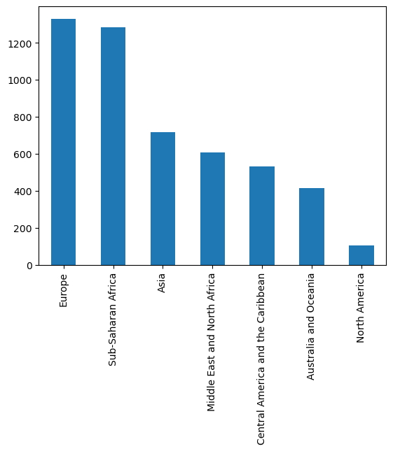

```python
df_sales["Region"].value_counts().plot.bar()
```

```python
df_sales["Region"].value_counts()
```

```
Europe                               1330
Sub-Saharan Africa                   1285
Asia                                  719
Middle East and North Africa          610
Central America and the Caribbean     534
Australia and Oceania                 416
North America                         106
Name: Region, dtype: int64
```

```
<BarContainer object of 7 artists>
```

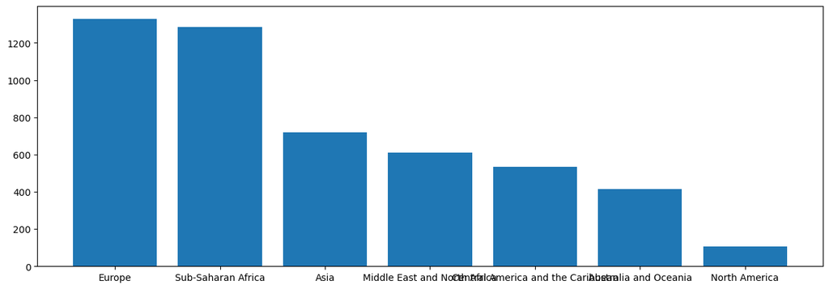

```python
x = df_sales['Region'].value_counts()
plt.figure(figsize=(15,5))

plt.bar(x.index, x.values)
```

```python
df_sales['Region'].unique()
```

```
array(['Central America and the Caribbean', 'Europe', 'Asia',
       'Middle East and North Africa', 'Australia and Oceania',
       'Sub-Saharan Africa', 'North America'], dtype=object)
```

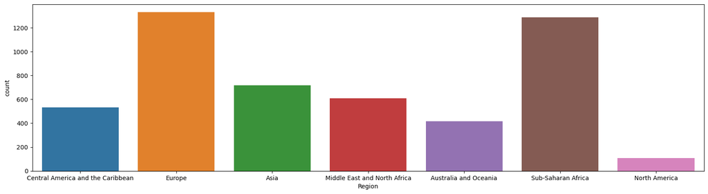

```python
import pandas as pd
import seaborn as sns
import matplotlib.pyplot as plt
plt.figure(figsize=(20,5))
sns.countplot(x='Region', data=df_sales)
```

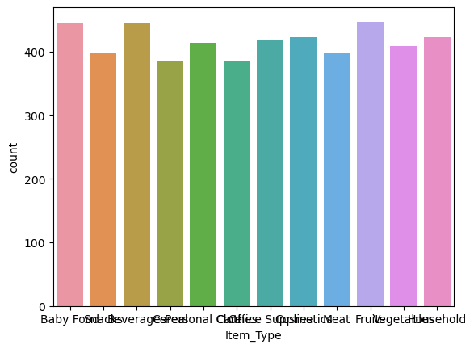

```python
import pandas as pd
import seaborn as sns
import matplotlib.pyplot as plt

sns.countplot(x='Item_Type', data=df_sales)
```

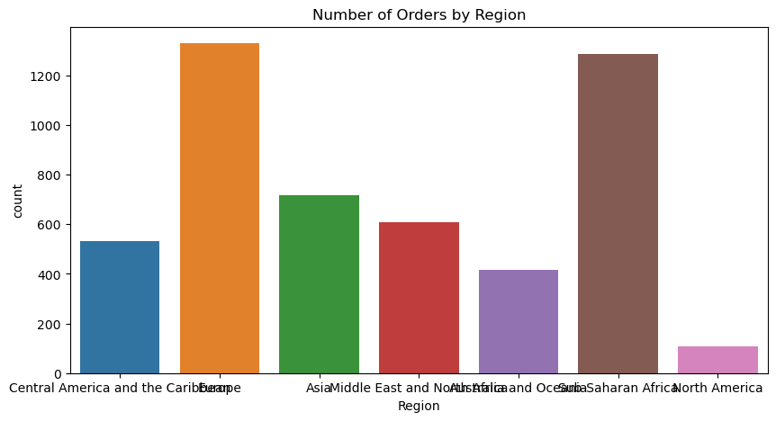

```python
plt.figure(figsize=(10,5))
plt.title('Number of Orders by Region')
sns.countplot(x='Region', data=df_sales)
```

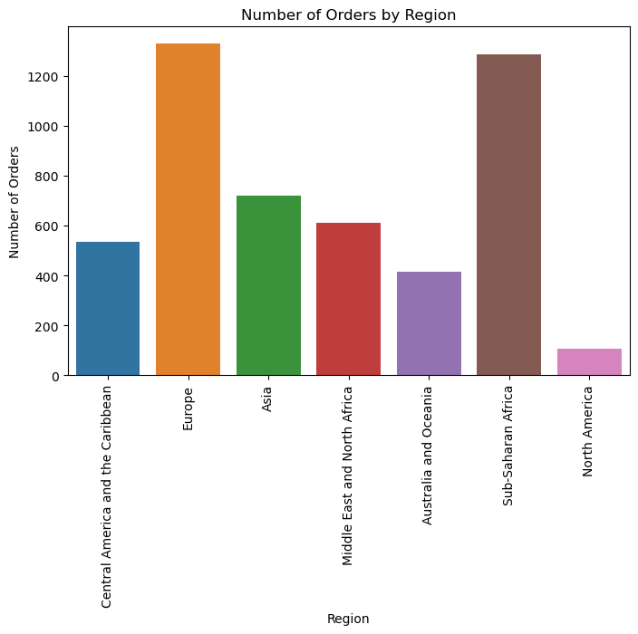

```python
plt.figure(figsize=(8,5))
sns.countplot(x='Region', data=df_sales)
plt.title('Number of Orders by Region')
plt.ylabel('Number of Orders')
plt.xlabel('Region')
plt.xticks(rotation = 90)
plt.show()
```

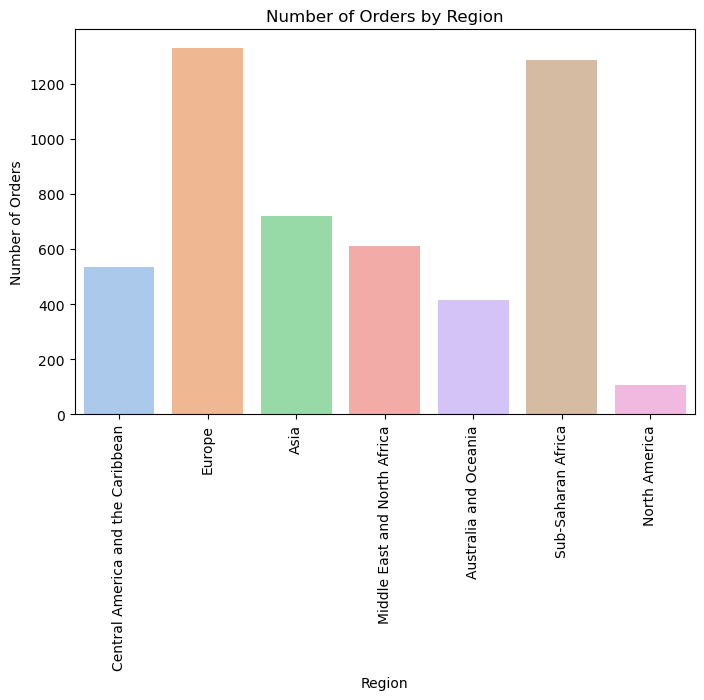

```python
plt.figure(figsize=(8,5))
sns.countplot(x='Region', data=df_sales,palette="pastel")
plt.title('Number of Orders by Region')
plt.ylabel('Number of Orders')
plt.xlabel('Region')
plt.xticks(rotation = 90)
plt.show()
```

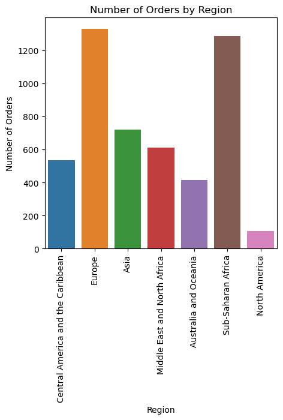

```python
plt.figure(figsize=(5,5))
sns.countplot(x='Region', data=df_sales)
plt.title('Number of Orders by Region')
plt.ylabel('Number of Orders')
plt.xlabel('Region')
plt.xticks(rotation = 90)
plt.show()
```

## Pie Chart

A pie chart is best used when trying to work out the composition of something. If you have categorical data then using a pie chart would work really well as each slice can represent a different category.

A pie chart is a circular graph that is broken down into segments (i.e slices of pie). These segments represent each category's contribution to display parts of a whole.

Pie charts are probably better than any other visual for expressing a part-to-whole relationship. When you hear “percent of…” or “part of…” that’s one indication a pie chart could meet your needs.

```python
a= df_sales["Region"].value_counts()
a
```

```
Europe                               1330
Sub-Saharan Africa                   1285
Asia                                  719
Middle East and North Africa          610
Central America and the Caribbean     534
Australia and Oceania                 416
North America                         106
Name: Region, dtype: int64
```

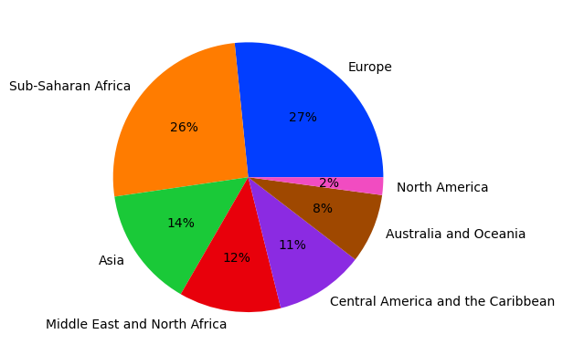

```python
#define Seaborn color palette to use
k = sns.color_palette('bright')[0:7]
plt.pie(a.values, labels = a.index,colors=k, autopct='%.0f%%')
plt.show()
```

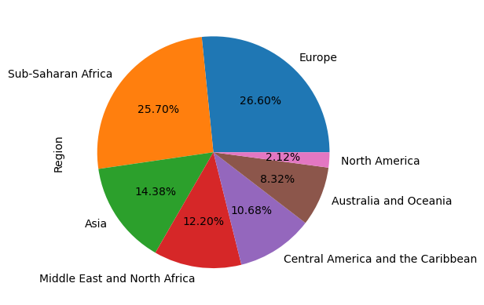

```python
df_sales["Region"].value_counts().plot.pie(autopct="%.2f%%")
```

```python
a = pd.DataFrame(df_sales["Region"].value_counts())
a
```

|  | Region |
| --- | --- |
| Europe | 1330 |
| Sub-Saharan Africa | 1285 |
| Asia | 719 |
| Middle East and North Africa | 610 |
| Central America and the Caribbean | 534 |
| Australia and Oceania | 416 |
| North America | 106 |

```python
1330/df_sales['Region'].count()
```

```
0.266
```

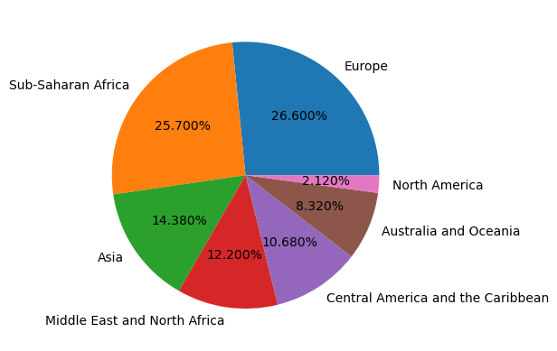

```python
plt.pie(a["Region"], labels = a.index, autopct='%.3f%%')
plt.show()
```

```python
a
```

[output not shown]

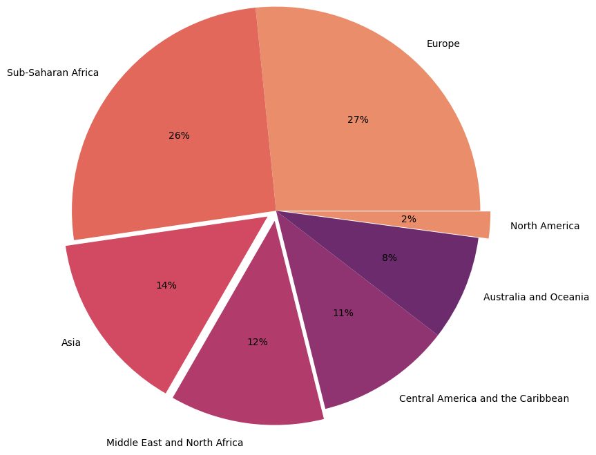

```python
k = sns.color_palette("flare")
plt.pie(a.values, labels = a.index,colors=k, autopct='%.0f%%',explode=[0,0,0.1,0.1,0,0,0.1],radius=2)
plt.show()
```

https://seaborn.pydata.org/tutorial/color_palettes.html

### Insights ?

**Numerical Data** - **Quantitative**

Numerical data are values that we can perform mathematical operations on. They are further broken down into continuous and discrete data types.  
**Discrete variables** have to be an integer. Number of items sold  
**Continuous** can be any value. Examples here include height and weight.

Numerical data can be visualized with a histogram. Histograms are a great first analysis of continuous data.

Four main aspects to consider here are **shape, center, spread**.

Shape is the overall appearance of the histogram. It can be symmetric, skewed, uniform, or have multiple peaks. Center refers to the mean or median.  
Spread refers to the range or how far the data reaches.  
Outliers are data points that fall far from the bulk of the data.  
A histogram groups values into bins of equal value range.

```python
df_titanic.columns
```

```
Index(['PassengerId', 'Survived', 'Pclass', 'Name', 'Sex', 'Age', 'SibSp',
       'Parch', 'Ticket', 'Fare', 'Cabin', 'Embarked'],
      dtype='object')
```

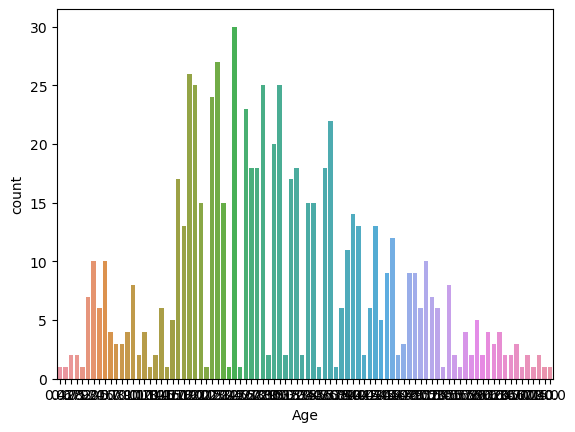

```python
sns.countplot(x='Age', data=df_titanic)
```

## Histograms

Histograms are sometimes confused with bar charts. A histogram is used for continuous data, where the bins represent ranges of data, while a bar chart is a plot of categorical variables.

A frequency distribution shows how often each different value in a set of data occurs. A histogram is the most commonly used graph to show frequency distributions.

To construct a histogram from a continuous variable you first need to split the data into intervals, called bins.

Each bin contains the number of occurrences of scores in the data set that are contained within that bin.

The Seaborn function to make histogram is “distplot” for distribution plot. As usual, Seaborn’s distplot can take the column from Pandas dataframe as argument to make histogram.

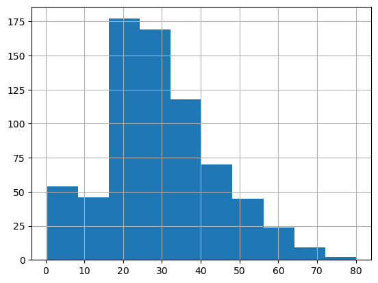

```python
df_titanic["Age"].hist()
```

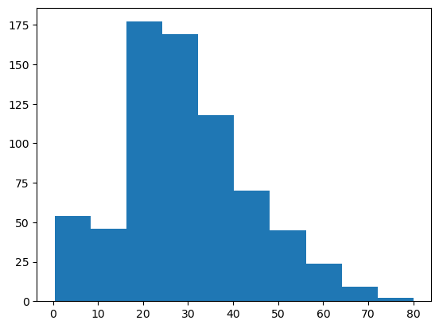

```python
plt.hist(df_titanic["Age"])
```

```python
df_titanic["Age"].min()
```

```
0.42
```

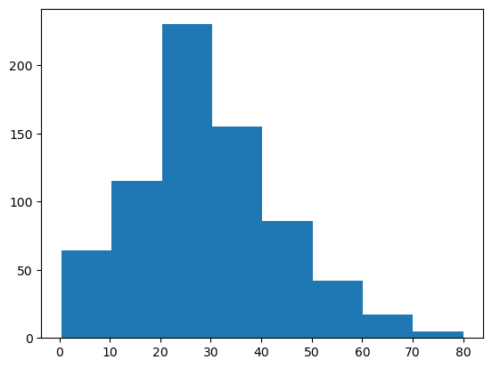

```python
plt.hist(df_titanic["Age"],bins=8)
```

displot by default will give us histograms

we can also change the displot to gives probabilities by using kind="kde"

we also have separately the kdeplots and hist plots as well

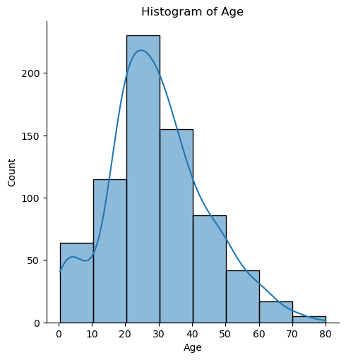

```python
sns.displot(df_titanic["Age"],kde=True,bins=8)
plt.title('Histogram of Age')
plt.show()
```

```python
df_titanic["Age"]
```

```
0      22.0
1      38.0
2      26.0
3      35.0
4      35.0
       ...
886    27.0
887    19.0
888     NaN
889    26.0
890    32.0
Name: Age, Length: 891, dtype: float64
```

```python
df_titanic['Age'].min()
```

```
0.42
```

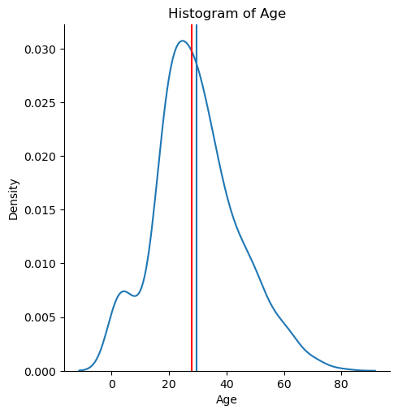

```python
sns.displot(df_titanic["Age"], kind='kde')
plt.title('Histogram of Age')
plt.axvline(df_titanic['Age'].mean())
plt.axvline(df_titanic['Age'].median(),color="red")
plt.show()
```

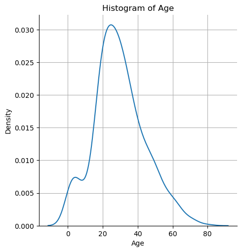

```python
sns.displot(df_titanic["Age"], kind='kde')
plt.title('Histogram of Age')
plt.grid()
plt.show()
```

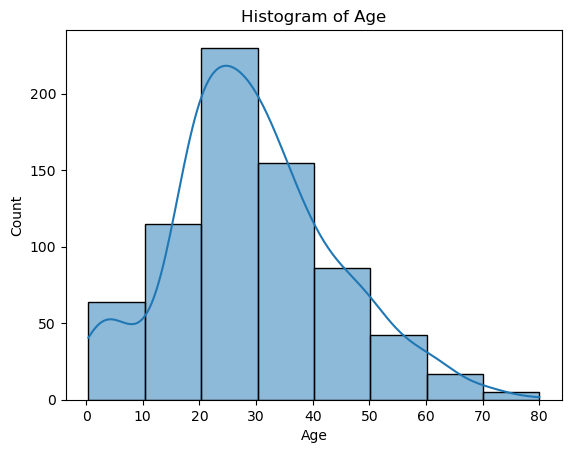

```python
sns.histplot(df_titanic["Age"],kde=True,bins=8)
plt.title('Histogram of Age')
plt.show()
```

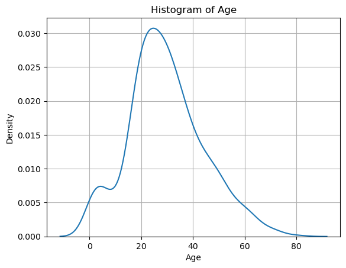

```python
sns.kdeplot(df_titanic["Age"])
plt.title('Histogram of Age')
plt.grid()
plt.show()
```

Histograms are best suited for looking at the distribution of numerical variables while bar plots/count plots are used for categorical features.  
The values on the X-axis in the histogram are numerical; a bar plot can have any type of values on the X-axis: numbers, strings, booleans.

### Boxplot

A box-plot is a very useful and standardized way of displaying the distribution of data based on a five-number summary (minimum, first quartile, second quartile(median), third quartile, maximum). It helps in understanding these parameters of the distribution of data and is extremely helpful in detecting outliers.

Its components are a box (obviously, this is why it is called a box plot), the so-called whiskers, and a number of individual points (outliers).

The box by itself illustrates the interquartile spread of the distribution; its length is determined by the 25th(Q1) and 75th(Q3) percentiles. The vertical line inside the box marks the median ( 50% ) of the distribution.

The whiskers are the lines extending from the box. They represent the entire scatter of data points, specifically the points that fall within the interval (Q1−1.5⋅IQR,Q3+1.5⋅IQR) , where IQR=Q3−Q1 is the interquartile range.

Outliers that fall outside of the range bounded by the whiskers are plotted individually as black points along the central axis.

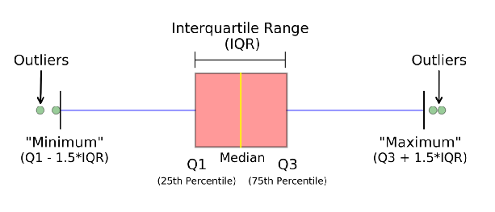

Boxplots are a standardized way of displaying the distribution of data based on a five number summary (“minimum”, first quartile (Q1), median, third quartile (Q3), and “maximum”).

median (Q2/50th Percentile): the middle value of the dataset.

first quartile (Q1/25th Percentile): the middle number between the smallest number (not the “minimum”) and the median of the dataset.

third quartile (Q3/75th Percentile): the middle value between the median and the highest value (not the “maximum”) of the dataset.

interquartile range (IQR): 25th to the 75th percentile.

whiskers (shown in blue)

outliers (shown as green circles)

“maximum”: Q3 + 1.5*IQR

“minimum”: Q1 -1.5*IQR

### Percentiles, Quartiles, and Interquartile Range

The pth percentile of a distribution is the value such that p percent of the observations fall at or below it.

The most commonly used percentiles other than the median are the 25th percentile and the 75th percentile. The 25th percentile demarcates the first quartile, the median or 50th percentile demarcates the second quartile, the 75th percentile demarcates the third quartile, and the 100th percentile demarcates the fourth quartile.

The interquartile range represents the central portion of the distribution, and is calculated as the difference between the third quartile and the first quartile.

A quartile divides data into three points—a lower quartile, median, and upper quartile—to form four groups of the dataset. The lower quartile, or first quartile, is denoted as **Q1 and is the middle number that falls between the smallest value of the dataset and the median**. The second quartile, **Q2, is also the median**. The upper or third quartile, denoted as **Q3, is the central point that lies between the median and the highest number of the distribution.**

Now, we can map out the four groups formed from the quartiles. The first group of values contains the smallest number up to Q1; the second group includes Q1 to the median; the third set is the median to Q3; the fourth category comprises Q3 to the highest datapoint of the entire set.

Each quartile contains 25% of the total observations. Generally, the data is arranged from smallest to largest:

First quartile: the lowest 25% of numbers  
Second quartile: between 25.1% and 50% (up to the median)  
Third quartile: 51% to 75% (above the median)  
Fourth quartile: the highest 25% of numbers

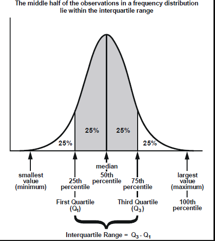

```python
import numpy as np
a=np.array([-1,2,4,5,6,7,10])
a
```

```
array([-1,  2,  4,  5,  6,  7, 10])
```

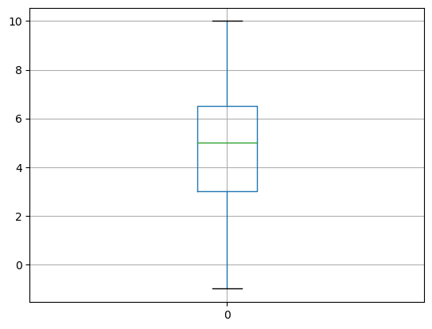

```python
pd.DataFrame(a).boxplot()
```

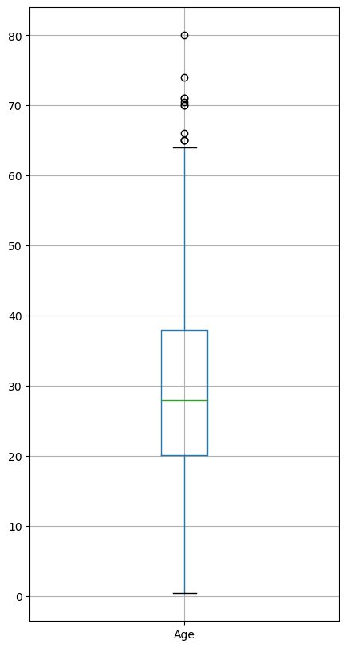

```python
plt.figure(figsize=(5,10))
df_titanic.boxplot(column="Age")
```

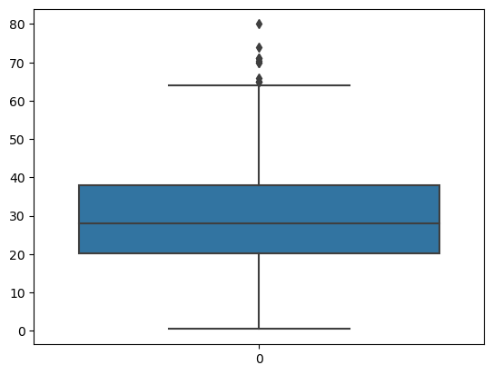

```python
sns.boxplot(df_titanic["Age"])
```

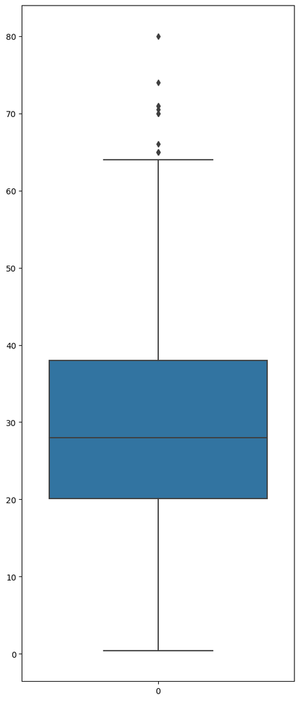

```python
plt.figure(figsize=(6,15))
sns.boxplot(df_titanic["Age"])
```

```python
Q1 = df_titanic["Age"].quantile(0.25)
Q3 = df_titanic["Age"].quantile(0.75)
print(Q1)
print(Q3)
IQR = Q3 - Q1
print(IQR)
```

```
20.125
38.0
17.875
```

```python
df_titanic['Age'].describe()
```

```
count    714.000000
mean      29.699118
std       14.526497
min        0.420000
25%       20.125000
50%       28.000000
75%       38.000000
max       80.000000
Name: Age, dtype: float64
```

```python
Q1-1.5*IQR
```

```
-6.6875
```

```python
Q3+1.5*IQR
```

```
64.8125
```

```python
df_titanic[(df_titanic['Age'] > Q3+1.5*IQR)]
```

|  | PassengerId | Survived | Pclass | Name | Sex | Age | SibSp | Parch | Ticket | Fare | Cabin | Embarked |
| --- | --- | --- | --- | --- | --- | --- | --- | --- | --- | --- | --- | --- |
| 33 | 34 | 0 | 2 | Wheadon, Mr. Edward H | male | 66.0 | 0 | 0 | C.A. 24579 | 10.5000 | NaN | S |
| 54 | 55 | 0 | 1 | Ostby, Mr. Engelhart Cornelius | male | 65.0 | 0 | 1 | 113509 | 61.9792 | B30 | C |
| 96 | 97 | 0 | 1 | Goldschmidt, Mr. George B | male | 71.0 | 0 | 0 | PC 17754 | 34.6542 | A5 | C |
| 116 | 117 | 0 | 3 | Connors, Mr. Patrick | male | 70.5 | 0 | 0 | 370369 | 7.7500 | NaN | Q |
| 280 | 281 | 0 | 3 | Duane, Mr. Frank | male | 65.0 | 0 | 0 | 336439 | 7.7500 | NaN | Q |
| 456 | 457 | 0 | 1 | Millet, Mr. Francis Davis | male | 65.0 | 0 | 0 | 13509 | 26.5500 | E38 | S |
| 493 | 494 | 0 | 1 | Artagaveytia, Mr. Ramon | male | 71.0 | 0 | 0 | PC 17609 | 49.5042 | NaN | C |
| 630 | 631 | 1 | 1 | Barkworth, Mr. Algernon Henry Wilson | male | 80.0 | 0 | 0 | 27042 | 30.0000 | A23 | S |
| 672 | 673 | 0 | 2 | Mitchell, Mr. Henry Michael | male | 70.0 | 0 | 0 | C.A. 24580 | 10.5000 | NaN | S |
| 745 | 746 | 0 | 1 | Crosby, Capt. Edward Gifford | male | 70.0 | 1 | 1 | WE/P 5735 | 71.0000 | B22 | S |
| 851 | 852 | 0 | 3 | Svensson, Mr. Johan | male | 74.0 | 0 | 0 | 347060 | 7.7750 | NaN | S |

```python
df_titanic[~(df_titanic['Age'] > Q3+1.5*IQR)].head(35)
```

|  | PassengerId | Survived | Pclass | Name | Sex | Age | SibSp | Parch | Ticket | Fare | Cabin | Embarked |
| --- | --- | --- | --- | --- | --- | --- | --- | --- | --- | --- | --- | --- |
| 0 | 1 | 0 | 3 | Braund, Mr. Owen Harris | male | 22.0 | 1 | 0 | A/5 21171 | 7.2500 | NaN | S |
| 1 | 2 | 1 | 1 | Cumings, Mrs. John Bradley (Florence Briggs Th... | female | 38.0 | 1 | 0 | PC 17599 | 71.2833 | C85 | C |
| 2 | 3 | 1 | 3 | Heikkinen, Miss. Laina | female | 26.0 | 0 | 0 | STON/O2. 3101282 | 7.9250 | NaN | S |
| 3 | 4 | 1 | 1 | Futrelle, Mrs. Jacques Heath (Lily May Peel) | female | 35.0 | 1 | 0 | 113803 | 53.1000 | C123 | S |
| 4 | 5 | 0 | 3 | Allen, Mr. William Henry | male | 35.0 | 0 | 0 | 373450 | 8.0500 | NaN | S |
| 5 | 6 | 0 | 3 | Moran, Mr. James | male | NaN | 0 | 0 | 330877 | 8.4583 | NaN | Q |
| 6 | 7 | 0 | 1 | McCarthy, Mr. Timothy J | male | 54.0 | 0 | 0 | 17463 | 51.8625 | E46 | S |
| 7 | 8 | 0 | 3 | Palsson, Master. Gosta Leonard | male | 2.0 | 3 | 1 | 349909 | 21.0750 | NaN | S |
| 8 | 9 | 1 | 3 | Johnson, Mrs. Oscar W (Elisabeth Vilhelmina Berg) | female | 27.0 | 0 | 2 | 347742 | 11.1333 | NaN | S |
| 9 | 10 | 1 | 2 | Nasser, Mrs. Nicholas (Adele Achem) | female | 14.0 | 1 | 0 | 237736 | 30.0708 | NaN | C |
| 10 | 11 | 1 | 3 | Sandstrom, Miss. Marguerite Rut | female | 4.0 | 1 | 1 | PP 9549 | 16.7000 | G6 | S |
| 11 | 12 | 1 | 1 | Bonnell, Miss. Elizabeth | female | 58.0 | 0 | 0 | 113783 | 26.5500 | C103 | S |
| 12 | 13 | 0 | 3 | Saundercock, Mr. William Henry | male | 20.0 | 0 | 0 | A/5. 2151 | 8.0500 | NaN | S |
| 13 | 14 | 0 | 3 | Andersson, Mr. Anders Johan | male | 39.0 | 1 | 5 | 347082 | 31.2750 | NaN | S |
| 14 | 15 | 0 | 3 | Vestrom, Miss. Hulda Amanda Adolfina | female | 14.0 | 0 | 0 | 350406 | 7.8542 | NaN | S |
| 15 | 16 | 1 | 2 | Hewlett, Mrs. (Mary D Kingcome) | female | 55.0 | 0 | 0 | 248706 | 16.0000 | NaN | S |
| 16 | 17 | 0 | 3 | Rice, Master. Eugene | male | 2.0 | 4 | 1 | 382652 | 29.1250 | NaN | Q |
| 17 | 18 | 1 | 2 | Williams, Mr. Charles Eugene | male | NaN | 0 | 0 | 244373 | 13.0000 | NaN | S |
| 18 | 19 | 0 | 3 | Vander Planke, Mrs. Julius (Emelia Maria Vande... | female | 31.0 | 1 | 0 | 345763 | 18.0000 | NaN | S |
| 19 | 20 | 1 | 3 | Masselmani, Mrs. Fatima | female | NaN | 0 | 0 | 2649 | 7.2250 | NaN | C |
| 20 | 21 | 0 | 2 | Fynney, Mr. Joseph J | male | 35.0 | 0 | 0 | 239865 | 26.0000 | NaN | S |
| 21 | 22 | 1 | 2 | Beesley, Mr. Lawrence | male | 34.0 | 0 | 0 | 248698 | 13.0000 | D56 | S |
| 22 | 23 | 1 | 3 | McGowan, Miss. Anna "Annie" | female | 15.0 | 0 | 0 | 330923 | 8.0292 | NaN | Q |
| 23 | 24 | 1 | 1 | Sloper, Mr. William Thompson | male | 28.0 | 0 | 0 | 113788 | 35.5000 | A6 | S |
| 24 | 25 | 0 | 3 | Palsson, Miss. Torborg Danira | female | 8.0 | 3 | 1 | 349909 | 21.0750 | NaN | S |
| 25 | 26 | 1 | 3 | Asplund, Mrs. Carl Oscar (Selma Augusta Emilia... | female | 38.0 | 1 | 5 | 347077 | 31.3875 | NaN | S |
| 26 | 27 | 0 | 3 | Emir, Mr. Farred Chehab | male | NaN | 0 | 0 | 2631 | 7.2250 | NaN | C |
| 27 | 28 | 0 | 1 | Fortune, Mr. Charles Alexander | male | 19.0 | 3 | 2 | 19950 | 263.0000 | C23 C25 C27 | S |
| 28 | 29 | 1 | 3 | O'Dwyer, Miss. Ellen "Nellie" | female | NaN | 0 | 0 | 330959 | 7.8792 | NaN | Q |
| 29 | 30 | 0 | 3 | Todoroff, Mr. Lalio | male | NaN | 0 | 0 | 349216 | 7.8958 | NaN | S |
| 30 | 31 | 0 | 1 | Uruchurtu, Don. Manuel E | male | 40.0 | 0 | 0 | PC 17601 | 27.7208 | NaN | C |
| 31 | 32 | 1 | 1 | Spencer, Mrs. William Augustus (Marie Eugenie) | female | NaN | 1 | 0 | PC 17569 | 146.5208 | B78 | C |
| 32 | 33 | 1 | 3 | Glynn, Miss. Mary Agatha | female | NaN | 0 | 0 | 335677 | 7.7500 | NaN | Q |
| 34 | 35 | 0 | 1 | Meyer, Mr. Edgar Joseph | male | 28.0 | 1 | 0 | PC 17604 | 82.1708 | NaN | C |
| 35 | 36 | 0 | 1 | Holverson, Mr. Alexander Oskar | male | 42.0 | 1 | 0 | 113789 | 52.0000 | NaN | S |

### Violin Plot

Violin plots are similar to boxplot, Violin plot shows the density of the data at different values nicely in addition to the range of data like boxplot.

A violin plot plays a similar role as a box and whisker plot. It shows the distribution of quantitative data across several levels of one (or more) categorical variables such that those distributions can be compared. Unlike a box plot, in which all of the plot components correspond to actual datapoints, the violin plot features a kernel density estimation of the underlying distribution.

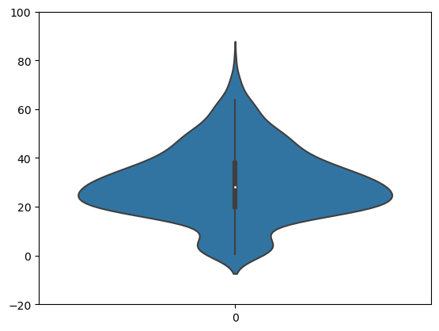

```python
import seaborn as sns
import matplotlib.pyplot as plt
plt.ylim(-20,100)
sns.violinplot(df_titanic["Age"])
```

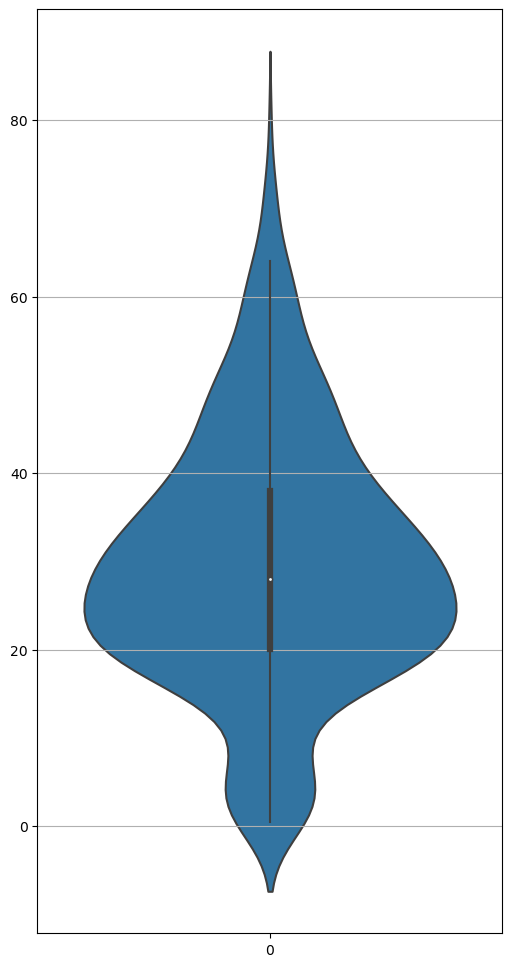

```python
import seaborn as sns
import matplotlib.pyplot as plt
plt.figure(figsize=(6,12))
plt.grid()
sns.violinplot(df_titanic["Age"])
```

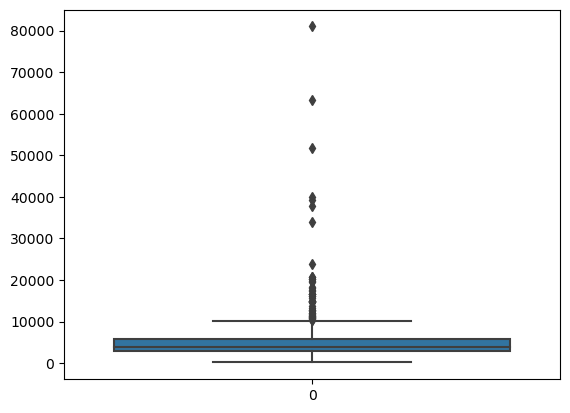

```python
sns.boxplot(df_loan["ApplicantIncome"])
```

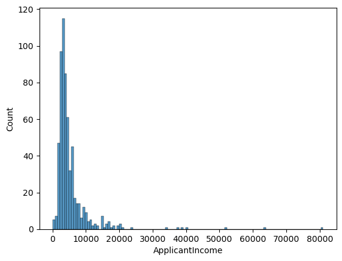

```python
sns.histplot(df_loan["ApplicantIncome"])
```

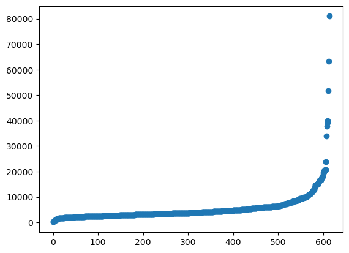

```python
plt.scatter(df_loan.index,df_loan["ApplicantIncome"])
```

```
(600.0, 615.0)
```

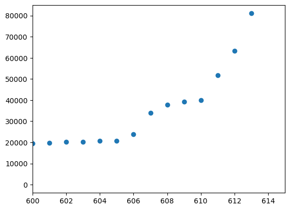

```python
plt.scatter(df_loan.index,df_loan["ApplicantIncome"])
plt.xlim([600,615])
```

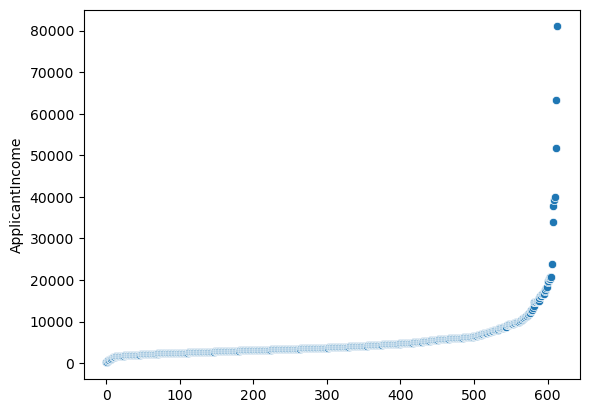

```python
sns.scatterplot(x=df_loan.index,y=df_loan["ApplicantIncome"])
```

```python
import numpy as np
outliers = []
def detect_outliers_iqr(data):
    data = sorted(data)
    q1 = np.percentile(data, 25)
    q3 = np.percentile(data, 75)
    print(q1, q3)
    IQR = q3-q1
    lwr_bound = q1-(1.5*IQR)
    upr_bound = q3+(1.5*IQR)
    print(lwr_bound, upr_bound)
    for i in data:
        if (i<lwr_bound or i>upr_bound):
            outliers.append(i)
    return outliers# Driver code

sample_outliers = detect_outliers_iqr(df_loan["ApplicantIncome"])
sample_outliers
```

```
2877.5 5795.0
-1498.75 10171.25
```

```
[10408,
 10416,
 10513,
 10750,
 10833,
 11000,
 11146,
 11250,
 11417,
 11500,
 11757,
 12000,
 12000,
 12500,
 12841,
 12876,
 13262,
 13650,
 14583,
 14583,
 14683,
 14866,
 14880,
 14999,
 15000,
 15759,
 16120,
 16250,
 16525,
 16666,
 16667,
 16692,
 17263,
 17500,
 18165,
 18333,
 19484,
 19730,
 20166,
 20233,
 20667,
 20833,
 23803,
 33846,
 37719,
 39147,
 39999,
 51763,
 63337,
 81000]
```

```python
len(sample_outliers)
```

```
50
```

```python
outliers=df_loan[df_loan["ApplicantIncome"].isin(sample_outliers)]
outliers
```

|  | Loan_ID | Gender | Married | Dependents | Education | Self_Employed | ApplicantIncome | CoapplicantIncome | LoanAmount | Loan_Amount_Term | Credit_History | Property_Area | Loan_Status |
| --- | --- | --- | --- | --- | --- | --- | --- | --- | --- | --- | --- | --- | --- |
| 564 | LP001422 | Female | No | 0 | Graduate | No | 10408 | 0.0 | 259.0 | 360.0 | 1.0 | Urban | Y |
| 565 | LP002403 | Male | No | 0 | Graduate | Yes | 10416 | 0.0 | 187.0 | 360.0 | 0.0 | Urban | N |
| 566 | LP001451 | Male | Yes | 1 | Graduate | Yes | 10513 | 3850.0 | 160.0 | 180.0 | 0.0 | Urban | N |
| 567 | LP001233 | Male | Yes | 1 | Graduate | No | 10750 | 0.0 | 312.0 | 360.0 | 1.0 | Urban | Y |
| 568 | LP002541 | Male | Yes | 0 | Graduate | No | 10833 | 0.0 | 234.0 | 360.0 | 1.0 | Semiurban | Y |
| 569 | LP001673 | Male | No | 0 | Graduate | Yes | 11000 | 0.0 | 83.0 | 360.0 | 1.0 | Urban | N |
| 570 | LP001891 | Male | Yes | 0 | Graduate | No | 11146 | 0.0 | 136.0 | 360.0 | 1.0 | Urban | Y |
| 571 | LP002729 | Male | No | 1 | Graduate | No | 11250 | 0.0 | 196.0 | 360.0 | NaN | Semiurban | N |
| 572 | LP001369 | Male | Yes | 2 | Graduate | No | 11417 | 1126.0 | 225.0 | 360.0 | 1.0 | Urban | Y |
| 573 | LP001186 | Female | Yes | 1 | Graduate | Yes | 11500 | 0.0 | 286.0 | 360.0 | 0.0 | Urban | N |
| 574 | LP001508 | Male | Yes | 2 | Graduate | No | 11757 | 0.0 | 187.0 | 180.0 | 1.0 | Urban | Y |
| 575 | LP001656 | Male | No | 0 | Graduate | No | 12000 | 0.0 | 164.0 | 360.0 | 1.0 | Semiurban | N |
| 576 | LP002959 | Female | Yes | 1 | Graduate | No | 12000 | 0.0 | 496.0 | 360.0 | 1.0 | Semiurban | Y |
| 577 | LP001100 | Male | No | 3+ | Graduate | No | 12500 | 3000.0 | 320.0 | 360.0 | 1.0 | Rural | N |
| 578 | LP001020 | Male | Yes | 1 | Graduate | No | 12841 | 10968.0 | 349.0 | 360.0 | 1.0 | Semiurban | N |
| 579 | LP002386 | Male | No | 0 | Graduate | NaN | 12876 | 0.0 | 405.0 | 360.0 | 1.0 | Semiurban | Y |
| 580 | LP002634 | Female | No | 1 | Graduate | No | 13262 | 0.0 | 40.0 | 360.0 | 1.0 | Urban | Y |
| 581 | LP001350 | Male | Yes | NaN | Graduate | No | 13650 | 0.0 | NaN | 360.0 | 1.0 | Urban | Y |
| 582 | LP001401 | Male | Yes | 1 | Graduate | No | 14583 | 0.0 | 185.0 | 180.0 | 1.0 | Rural | Y |
| 583 | LP001907 | Male | Yes | 0 | Graduate | No | 14583 | 0.0 | 436.0 | 360.0 | 1.0 | Semiurban | Y |
| 584 | LP001859 | Male | Yes | 0 | Graduate | No | 14683 | 2100.0 | 304.0 | 360.0 | 1.0 | Rural | N |
| 585 | LP001516 | Female | Yes | 2 | Graduate | No | 14866 | 0.0 | 70.0 | 360.0 | 1.0 | Urban | Y |
| 586 | LP002364 | Male | Yes | 0 | Graduate | No | 14880 | 0.0 | 96.0 | 360.0 | 1.0 | Semiurban | Y |
| 587 | LP001492 | Male | No | 0 | Graduate | No | 14999 | 0.0 | 242.0 | 360.0 | 0.0 | Semiurban | N |
| 588 | LP002065 | Male | Yes | 3+ | Graduate | No | 15000 | 0.0 | 300.0 | 360.0 | 1.0 | Rural | Y |
| 589 | LP002194 | Female | No | 0 | Graduate | Yes | 15759 | 0.0 | 55.0 | 360.0 | 1.0 | Semiurban | Y |
| 590 | LP002938 | Male | Yes | 0 | Graduate | Yes | 16120 | 0.0 | 260.0 | 360.0 | 1.0 | Urban | Y |
| 591 | LP001844 | Male | No | 0 | Graduate | Yes | 16250 | 0.0 | 192.0 | 360.0 | 0.0 | Urban | N |
| 592 | LP002527 | Male | Yes | 2 | Graduate | Yes | 16525 | 1014.0 | 150.0 | 360.0 | 1.0 | Rural | Y |
| 593 | LP002855 | Male | Yes | 2 | Graduate | No | 16666 | 0.0 | 275.0 | 360.0 | 1.0 | Urban | Y |
| 594 | LP002531 | Male | Yes | 1 | Graduate | Yes | 16667 | 2250.0 | 86.0 | 360.0 | 1.0 | Semiurban | Y |
| 595 | LP002501 | NaN | Yes | 0 | Graduate | No | 16692 | 0.0 | 110.0 | 360.0 | 1.0 | Semiurban | Y |
| 596 | LP002582 | Female | No | 0 | Not Graduate | Yes | 17263 | 0.0 | 225.0 | 360.0 | 1.0 | Semiurban | Y |
| 597 | LP002699 | Male | Yes | 2 | Graduate | Yes | 17500 | 0.0 | 400.0 | 360.0 | 1.0 | Rural | Y |
| 598 | LP002731 | Female | No | 0 | Not Graduate | Yes | 18165 | 0.0 | 125.0 | 360.0 | 1.0 | Urban | Y |
| 599 | LP002547 | Male | Yes | 1 | Graduate | No | 18333 | 0.0 | 500.0 | 360.0 | 1.0 | Urban | N |
| 600 | LP002813 | Female | Yes | 1 | Graduate | Yes | 19484 | 0.0 | 600.0 | 360.0 | 1.0 | Semiurban | Y |
| 601 | LP002191 | Male | Yes | 0 | Graduate | No | 19730 | 5266.0 | 570.0 | 360.0 | 1.0 | Rural | N |
| 602 | LP001469 | Male | No | 0 | Graduate | Yes | 20166 | 0.0 | 650.0 | 480.0 | NaN | Urban | Y |
| 603 | LP001996 | Male | No | 0 | Graduate | No | 20233 | 0.0 | 480.0 | 360.0 | 1.0 | Rural | N |
| 604 | LP001922 | Male | Yes | 0 | Graduate | No | 20667 | 0.0 | NaN | 360.0 | 1.0 | Rural | N |
| 605 | LP002624 | Male | Yes | 0 | Graduate | No | 20833 | 6667.0 | 480.0 | 360.0 | NaN | Urban | Y |
| 606 | LP001448 | NaN | Yes | 3+ | Graduate | No | 23803 | 0.0 | 370.0 | 360.0 | 1.0 | Rural | Y |
| 607 | LP001637 | Male | Yes | 1 | Graduate | No | 33846 | 0.0 | 260.0 | 360.0 | 1.0 | Semiurban | N |
| 608 | LP002422 | Male | No | 1 | Graduate | No | 37719 | 0.0 | 152.0 | 360.0 | 1.0 | Semiurban | Y |
| 609 | LP001640 | Male | Yes | 0 | Graduate | Yes | 39147 | 4750.0 | 120.0 | 360.0 | 1.0 | Semiurban | Y |
| 610 | LP001536 | Male | Yes | 3+ | Graduate | No | 39999 | 0.0 | 600.0 | 180.0 | 0.0 | Semiurban | Y |
| 611 | LP001585 | NaN | Yes | 3+ | Graduate | No | 51763 | 0.0 | 700.0 | 300.0 | 1.0 | Urban | Y |
| 612 | LP002101 | Male | Yes | 0 | Graduate | NaN | 63337 | 0.0 | 490.0 | 180.0 | 1.0 | Urban | Y |
| 613 | LP002317 | Male | Yes | 3+ | Graduate | No | 81000 | 0.0 | 360.0 | 360.0 | 0.0 | Rural | N |

# Handle Outliers

1. Trimming/Remove the outliers

```python
not_outliers=~df_loan["ApplicantIncome"].isin(sample_outliers)
not_outliers
```

```
0       True
1       True
2       True
3       True
4       True
       ...
609    False
610    False
611    False
612    False
613    False
Name: ApplicantIncome, Length: 614, dtype: bool
```

```python
df_loan[not_outliers]
```

|  | Loan_ID | Gender | Married | Dependents | Education | Self_Employed | ApplicantIncome | CoapplicantIncome | LoanAmount | Loan_Amount_Term | Credit_History | Property_Area | Loan_Status |
| --- | --- | --- | --- | --- | --- | --- | --- | --- | --- | --- | --- | --- | --- |
| 0 | LP001722 | Male | Yes | 0 | Graduate | No | 150 | 1800.0 | 135.0 | 360.0 | 1.0 | Rural | N |
| 1 | LP002502 | Female | Yes | 2 | Not Graduate | NaN | 210 | 2917.0 | 98.0 | 360.0 | 1.0 | Semiurban | Y |
| 2 | LP002949 | Female | No | 3+ | Graduate | NaN | 416 | 41667.0 | 350.0 | 180.0 | NaN | Urban | N |
| 3 | LP002603 | Female | No | 0 | Graduate | No | 645 | 3683.0 | 113.0 | 480.0 | 1.0 | Rural | Y |
| 4 | LP001644 | NaN | Yes | 0 | Graduate | Yes | 674 | 5296.0 | 168.0 | 360.0 | 1.0 | Rural | Y |
| ... | ... | ... | ... | ... | ... | ... | ... | ... | ... | ... | ... | ... | ... |
| 559 | LP001519 | Female | No | 0 | Graduate | No | 10000 | 1666.0 | 225.0 | 360.0 | 1.0 | Rural | N |
| 560 | LP001708 | Female | No | 0 | Graduate | No | 10000 | 0.0 | 214.0 | 360.0 | 1.0 | Semiurban | N |
| 561 | LP002050 | Male | Yes | 1 | Graduate | Yes | 10000 | 0.0 | 155.0 | 360.0 | 1.0 | Rural | N |
| 562 | LP002393 | Female | NaN | NaN | Graduate | No | 10047 | 0.0 | NaN | 240.0 | 1.0 | Semiurban | Y |
| 563 | LP002795 | Male | Yes | 3+ | Graduate | Yes | 10139 | 0.0 | 260.0 | 360.0 | 1.0 | Semiurban | Y |

564 rows × 13 columns

2. Mean/Median Imputation

```python
df_loan[not_outliers]["ApplicantIncome"]
```

```
0        150
1        210
2        416
3        645
4        674
       ...
559    10000
560    10000
561    10000
562    10047
563    10139
Name: ApplicantIncome, Length: 564, dtype: int64
```

```python
a=df_temp[(df_titanic['Age']<ll) |(df_titanic['Age']> ul)]['Age']
a
```

[output not shown]

```python
df_titanic.loc[df_temp['Age'].isin(a),'Age']=np.nan
df_temp['Age']
```

[output not shown]

```python
#replace nan with constant/mean/median and plot the boxplots
```

[output not shown]